# Dashboard for BirdLife LitScan scraper

Bill Oxbury

2022-10-22

*This file is updated automatically as part of the scraper processing.*

### First statistics

The [BlitScan app](https://blitscanapp.azurewebsites.net/) is built over a data set of journal articles/research publications:

```
## Number of articles: 10,848
```

```
## Number of species: 3,763
```

```
## Number of journals/proceedings: 473
```

```
## Number of publishers: 76
```

More detail on journals and publishers is given below. A full list of journals/proceedings the database draws from is given in the appendix.

### Red-list coverage

The counts in the table below are the numbers of species (normalised to *SISRecID* identifier and classified by red-list status) occuring in any title or abstract of the database, versus those occuring in the [BirdLife DataZone](http://datazone.birdlife.org/home).

| Status | Count | OutOf | Percent |
| --- | --- | --- | --- |
| LC | 2,342 | 8,459 | 27.7 |
| NT | 277 | 1,004 | 27.6 |
| VU | 257 | 768 | 33.5 |
| EN | 174 | 444 | 39.2 |
| CR | 107 | 197 | 54.3 |
| EX | 17 | 157 | 10.8 |
| DD | 6 | 50 | 12.0 |
| PE | 8 | 22 | 36.4 |
| EW | 5 | 5 | 100.0 |

(Note that the numbers in the *Count* column are underestimates and may not add up to the species count given above - this is because red-list status cannot always be ascertained. The numbers in the *OutOf* column are estimated by a crawl of DataZone pages.)

How many journal articles are we seeing per-species?

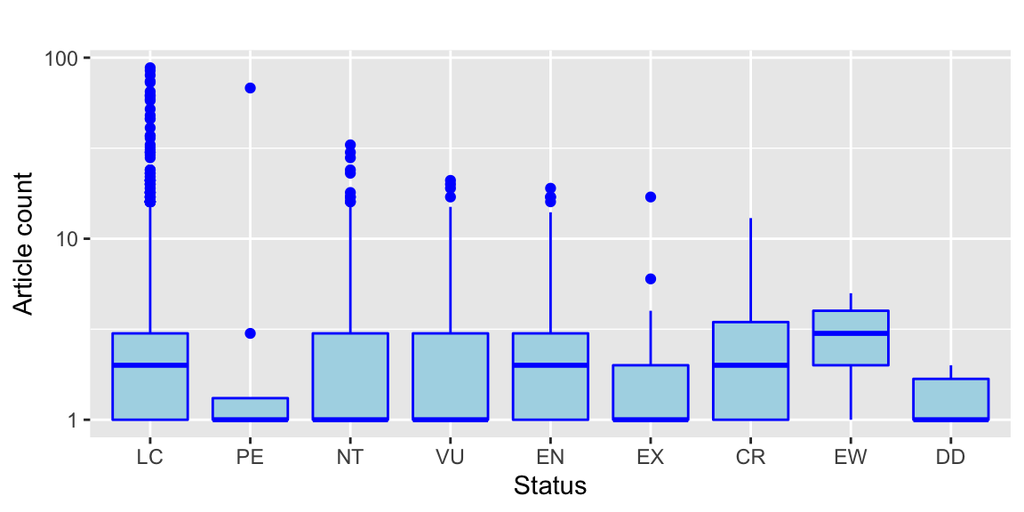

### Sources

The search process to find web content follows four main steps to identify articles, followed by text retrieval from those articles. These are:

1. Bing Custom Search against targeted domains
2. Scanning of [Open Archives Initiative](http://www.openarchives.org/OAI/openarchivesprotocol.html) API to get titles/abstracts from relevant contributors
3. Query of preprint archives against genus (Latin) names in vulnerable categories
4. Scanning of content lists for targeted journals.

#### Step 1: [Custom Search](https://docs.microsoft.com/en-us/bing/search-apis/bing-custom-search/overview)

This first step uses the full power of customised web search - previously using Google, now using Microsoft Bing. It gives us a wide reach, while the journal scans in the later steps ensure greater completeness.

The process manages the cost of search by sampling search terms at each run, with the aim of achieving repeated coverage of all search terms over time. Custom search runs queries against a set of targeted domains (which will be listed below after describing steps 2,3,4). Each query uses a random search term taken from a [list of generic scientific/common bird names](https://github.com/billoxbury/blitscan/blob/main/data/searchterms_general.txt) (while checking that the search hasn’t been used too recently).

URLs returned from this process are stored and mined individually *after* all of steps 1-4 have completed.

#### Step 2: [Open Archives Initiative (OAI)](http://www.openarchives.org/OAI/openarchivesprotocol.html)

OAI is a centralised service that collects research metadata, including titles/abstracts, from institutions and publishers around the world. On the one hand, it protects these providers from cyber threats if they permit web crawling directly to their servers; on the other hand, it greatly simplifies the process for data consumers in providing a single format across a very wide community of providers.

As of June 2022 there are 5,616 listed providers to OAI. Most of these are not relevant to conservation biology, and we are currently using OAI for access to just one provider [BioOne](https://bioone.org). Journals published by BioOne that we’re using as relevant to BirdLife are the following. (The count is the number of articles, from OAI access, currently in the BlitScan database.)

| Journal | Society | Publisher | Count |
| --- | --- | --- | --- |
| African Zoology | Zoological Society of Southern Africa | Informa UK Limited | 159 |
| Ardea | Netherlands Ornithologists’ Union | Netherlands Ornithologists’ Union | 127 |
| Ardeola | Spanish Society of Ornithology | Ardeola | 123 |
| Bulletin of the British Ornithologists’ Club | British Ornithologists’ Club | British Ornithologists’ Club | 125 |
| Bulletin of the British Ornithologists’ Club | British Ornithologists’ Club | British Ornithologists’ Club | 125 |
| Journal of East African Natural History | Nature Kenya/East African Natural History Society | East African Natural History Society | 27 |
| Journal of Raptor Research | Raptor Research Foundation | The Raptor Research Foundation, Inc. | 64 |
| Ornithological Science | The Ornithological Society of Japan | Ornithological Society of Japan | 101 |
| Ornithology | American Ornithological Society | Oxford University Press (OUP) | 86 |
| The Auk | American Ornithological Society | Oxford University Press (OUP) | 86 |
| The Southwestern Naturalist | Southwestern Association of Naturalists | Southwestern Association of Naturalists | 193 |
| The Wilson Journal of Ornithology | The Wilson Ornithological Society | Wilson Ornithological Society | 139 |
| Waterbirds | The Waterbird Society | Waterbird Society | 174 |
| Wildlife Biology | Nordic Board for Wildlife Research | Wiley | 194 |
| Zoological Science | Zoological Society of Japan | Zoological Society of Japan | 180 |

#### Step 3: preprint archives

Similar to step 1, except that instead of using a commercial search engine, queries are made directly to a set of preprint archives, currently consisting of:

| Archive | Language | URL | Count |
| --- | --- | --- | --- |
| bioRxiv | en | https://www.biorxiv.org/search/search_term | 2,283 |
| J-Stage | ja | https://www.jstage.jst.go.jp/result/global/-char/ja?globalSearchKey=search_term | 179 |

In the URLs above, ‘search_term’ is selected from a [list of scientific genus names containing vulnerable species](https://github.com/billoxbury/blitscan/blob/main/data/searchterms_restricted.csv) (that is, having red-list status not *LC* or *EX*).

URLs returned from this process are stored and mined individually after all of steps 1-4 have completed.

#### Step 4: journal contents listings

To add completeness beyond the quite general searches above, this step explicitly scans the tables of contents for recent issues of key journals. Those currently scanned are the following.

| Journal | Language | URL | Count |
| --- | --- | --- | --- |
| Avian Conservation & Ecology | fr | https://www.ace-eco.org | 59 |
| Avian Research | en | https://avianres.biomedcentral.com | 7 |
| Bird Conservation International | en | https://cambridge.org/core/journals/bird-conservation-international | 95 |
| Bird Study | en | https://www.tandfonline.com/toc/tbis20/current | 18 |
| Conservation Biology | en | https://conbio.onlinelibrary.wiley.com/journal/15231739 | 376 |
| Conservation Letters | en | https://conbio.onlinelibrary.wiley.com/journal/1755263x | 167 |
| Conservation Science & Practice | en | https://conbio.onlinelibrary.wiley.com/journal/25784854 | 421 |
| Emu - Austral Ornithology | en | https://www.tandfonline.com/toc/temu20/current | 49 |
| Journal of Ornithology | en | https://www.springer.com/journal/10336 | 202 |
| Ornitología Colombiana | es | https://asociacioncolombianadeornitologia.org/revista-ornitologia-colombiana/ | 23 |
| Ornitologia Neotropica | es | https://journals.sfu.ca/ornneo/index.php/ornneo/issue/archive | 100 |
| Oryx | en | https://www.cambridge.org/core/journals/oryx/all-issues | 180 |
| Ostrich - Journal of African Ornithology | en | https://www.nisc.co.za/products/11/journals/ostrich-journal-of-african-ornithology | 20 |
| PLOS ONE | en | https://journals.plos.org/plosone/browse/ | 403 |

#### Step 1 revisited - domains and issues arising

The initial custom search covers many more journals than those visited in steps 2-4 (see the appendix). This is possible by running searches against *domains* rather than individual journals or even publishers:

| Domain | Minable? | Count |
| --- | --- | --- |
| biorxiv.org | 1 | 2,463 |
| link.springer.com | 1 | 1,517 |
| conbio.onlinelibrary.wiley.com | 0 | 1,009 |
| journals.plos.org | 1 | 735 |
| nature.com | 1 | 700 |
| sciencedirect.com | 0 | 493 |
| cambridge.org | 1 | 484 |
| avianres.biomedcentral.com | 1 | 331 |
| ace-eco.org | 1 | 316 |
| tandfonline.com | 1 | 286 |
| jstage.jst.go.jp | 1 | 181 |
| journals.sfu.ca | 1 | 133 |
| orientalbirdclub.org | 1 | 57 |
| nisc.co.za | 1 | 55 |
| int-res.com | 1 | 25 |
| asociacioncolombianadeornitologia.org | 1 | 23 |
| sciendo.com | 1 | 22 |
| academic.oup.com | 0 | 21 |
| mexorn.org | 1 | 18 |
| birdlife.org.au | 1 | 0 |
| hilarispublisher.com | 0 | 0 |
| mdpi.com | 0 | 0 |
| omicsonline.org | 0 | 0 |
| meridian.allenpress.com | 0 | 0 |

The binary indicator ‘minable’ refers to domain policy which in some cases (minable = 0) prohibits or limits text extraction later on. Notable examples are *conbio.onlinelibrary.wiley.com* and *academic.oup.com*. In some cases we are able to work with these domains via open archive initiatives.

### Language coverage

We aim to grow the coverage of non-English language sources by taking advantage of cloud translation services.The current distribution of languages represented in the BlitScan database is as follows:

| language | Count | OutOf |
| --- | --- | --- |
| en | 10,160 | 12,302 |
| fr | 313 | 475 |
| es | 194 | 297 |
| ja | 181 | 1,410 |
| de | 0 | 2 |

In this table, ‘Count’ refers to the current database while ‘OutOf’ refers to the wider data set of articles that is stored before filtering down to the database used. Filtering is based on both date and relevance.

### Date range

The range and distribution of known dates of articles in the database:

```
## Date range 2016-10-14 to 2022-12-01
```

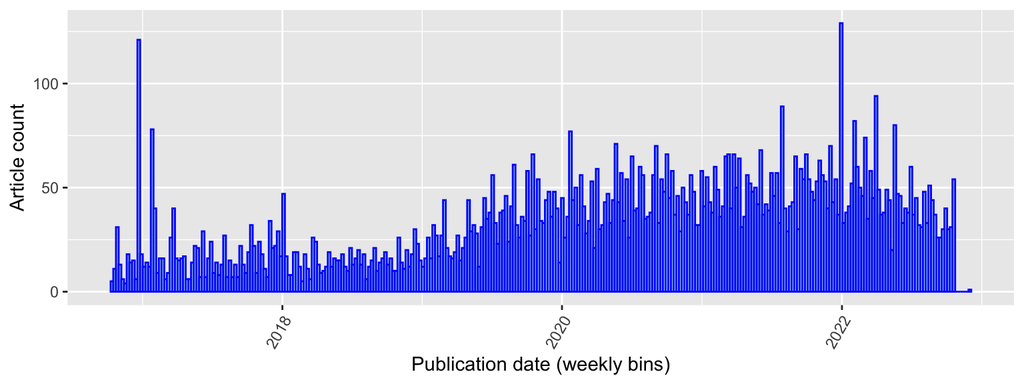

Note that points beyond today’s date usually indicate instances where publication comes later than online announcement.

Reading of dates can be a fallible process - how well are we able to parse publication dates for URLs?

```
## Proportion of records with date parsed: 98%
```

By domain this looks like:

```
##
## domain                                  FALSE TRUE
##   academic.oup.com                         17    4
##   ace-eco.org                               0  320
##   asociacioncolombianadeornitologia.org    23    0
##   avianres.biomedcentral.com                0  331
##   bioone.org                                0  116
##   bioone.org/action/oai                     0 1692
##   biorxiv.org                               0 2506
##   cambridge.org                             1  497
##   complete.bioone.org                      30    0
##   conbio.onlinelibrary.wiley.com            0 1009
##   int-res.com                               0   26
##   journals.plos.org                         0  735
##   journals.sfu.ca                           0  133
##   jstage.jst.go.jp                          0  181
##   link.springer.com                        35 1482
##   mexorn.org                                1   17
##   nature.com                               59  710
##   nisc.co.za                                0   57
##   orientalbirdclub.org                     50   15
##   sciencedirect.com                         0  493
##   sciendo.com                               0   22
##   tandfonline.com                           4  282
```

### Score distribution

Text retrieved is scored in the downstream *process* stage. Here is the overall distribution, with the quartiles/median marked in red.

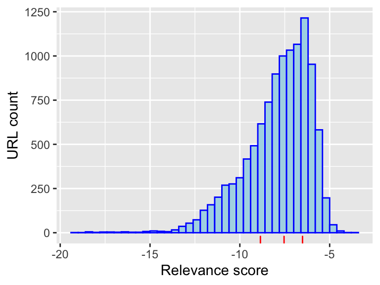

This score then provides a basis for comparing domains. (Note that the red quartile markers are those for the overall distribution and are the same for all subplots.) For clarity we only show domains exceeding a count threshold:

```
## Count threshold for plot:  30
```

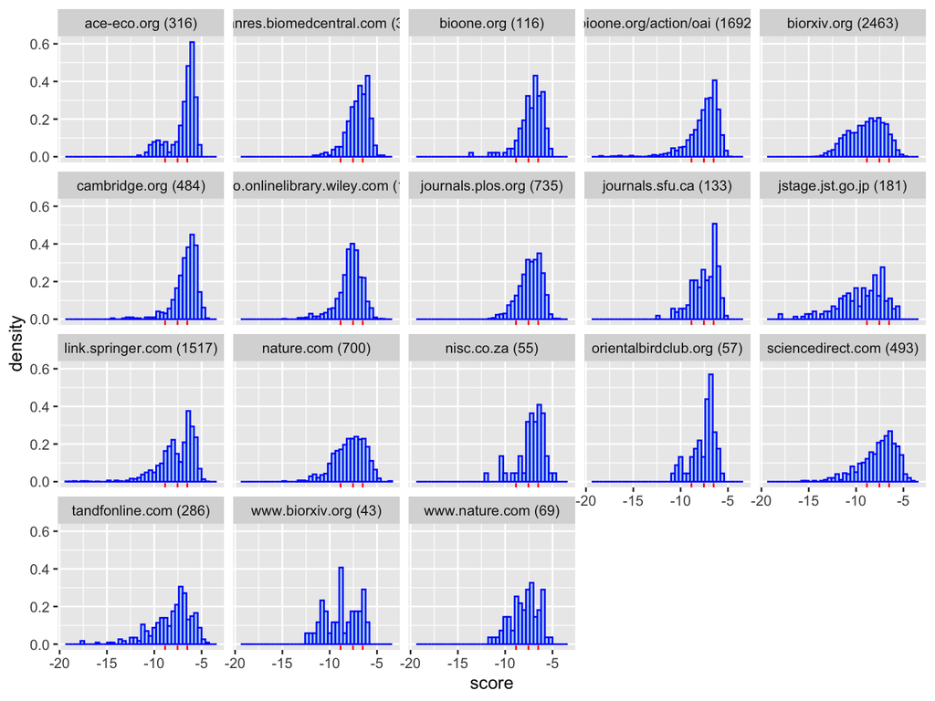

One can make some observations from this plot. For each domain, a skew to the right is good, to the left is not good.

First, the value of the OAI domain *bioone.org/action/oai* is showing clearly. (This represents the journals listed under ‘step 2’ above.) (Note that the domain *bioone.org* was mined directly for just the Wilson Journal prior to use of OAI.)

Second, the profile for *biorxiv.org* is less strong and could suggest a review of how the site is crawled.

Third, bimodal distributions (i.e. showing outlying lumps to the left) can indicate non-English text that has not yet been translated.

Finally, a visual check on *link.springer.com* is useful just because Springer turns out to dominate the journals visited by the custom search (step 1). (See the appendix.)

### Text retrieval

All of the above statistics refer to articles in the Blitscan database for which text has been successfully retrieved. But that represents a subset of a larger dataset of URLs (coming from steps 1-4 above) for which text retrieval was attempted. Here we summarise the success or not, by domain, of text retrieval on this fuller dataset.

We’ve indicated above (‘Step 1 revisited’) that not all domains consistently permit web crawling. Among responsive domains, the following counts show URLs from which text was retrieved (1) versus not (0):

```
##                                        text
## domain                                     0    1
##   academic.oup.com                       695   21
##   ace-eco.org                            166  489
##   asociacioncolombianadeornitologia.org   24  117
##   avianres.biomedcentral.com               5  361
##   bioone.org                            3252  116
##   bioone.org/action/oai                  830 1801
##   biorxiv.org                             12 2569
##   cambridge.org                          873 1106
##   complete.bioone.org                    682   30
##   conbio.onlinelibrary.wiley.com         885 1027
##   int-res.com                              0   87
##   journals.plos.org                        0  763
##   journals.sfu.ca                         56  145
##   jstage.jst.go.jp                      2329 1410
##   link.springer.com                     1077 2375
##   mexorn.org                               3   18
##   nature.com                              47  869
##   nisc.co.za                               1  182
##   orientalbirdclub.org                     0   65
##   sciencedirect.com                     2492  493
##   sciendo.com                              3   34
##   tandfonline.com                        396  408
```

### Appendix: list of all journals/proceedings

The listing below makes use of the open source project [CrossRef](https://www.crossref.org/). At each of the steps in the *scrape* process we record the [Digital Object Identifier (DOI)](https://www.doi.org/) of each article if possible.

```
## Proportion of articles with known DOI: 85.804%
```

CrossRef then allows us to query all of the known DOIs in the Blitscan database to obtain a rich set of metadata. The list below is extracted from that set:

| Journal | Publisher | Count |
| --- | --- | --- |
| PLOS ONE | Public Library of Science (PLoS) | 630 |
| Conservation Science and Practice | Wiley | 428 |
| Conservation Biology | Wiley | 380 |
| Scientific Reports | Springer Science and Business Media LLC | 345 |
| Journal of Ornithology | Springer Science and Business Media LLC | 268 |
| Avian Research | Elsevier BV | 248 |
| Oryx | Cambridge University Press (CUP) | 199 |
| Bird Conservation International | Cambridge University Press (CUP) | 193 |
| Wildlife Biology | Wiley | 192 |
| The Southwestern Naturalist | Southwestern Association of Naturalists | 190 |
| Zoological Science | Zoological Society of Japan | 180 |
| Waterbirds | Waterbird Society | 174 |
| Conservation Letters | Wiley | 166 |
| Avian Conservation and Ecology | Resilience Alliance, Inc. | 164 |
| African Zoology | Informa UK Limited | 162 |
| The Wilson Journal of Ornithology | Wilson Ornithological Society | 139 |
| Ardea | Netherlands Ornithologists’ Union | 127 |
| Ardeola | Ardeola | 123 |
| Ornithological Science | Ornithological Society of Japan | 106 |
| Bulletin of the British Ornithologists’ Club | British Ornithologists’ Club | 85 |
| The Auk | Oxford University Press (OUP) | 84 |
| Nature Communications | Springer Science and Business Media LLC | 83 |
| Nature | Springer Science and Business Media LLC | 66 |
| Journal of Raptor Research | The Raptor Research Foundation, Inc. | 64 |
| Emu - Austral Ornithology | Informa UK Limited | 56 |
| Ornithology Research | Springer Science and Business Media LLC | 48 |
| Biodiversity and Conservation | Springer Science and Business Media LLC | 45 |
| Bulletin of the British Ornithologists’ Club | British Ornithologists’ Club | 40 |
| Parasitology Research | Springer Science and Business Media LLC | 40 |
| Urban Ecosystems | Springer Science and Business Media LLC | 35 |

[output cut: 443 more lines]

### R and package versions used